# act_report

## Introduction

The Twitter account, WeRateDogs (https://twitter.com/dog_rates) was started in 2015 to rate user's dogs and comment on their pictures. The dogs are rated from 0 to 10 but a lot of ratings excess the maximum as an inner joke. The account rapidly became popular and has about 8.7 million followers.

During my project I analyzed the trends, related dog breeds, dog categories, dog rates and dog names, based on the number of favorites and the number of the account's tweets. I was also curious about the account's own categorical system and analyzed the proportions of the dog stages.

### Possible Correlations:

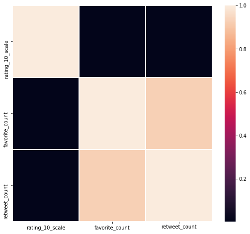

We can see that there is no correlation between rating and favorite count and retweet count, which makes sense as rating is "only" part of the site's joke and can be absolutely random, not reflecting any particular meaning. However, we can find a correlation between favorite count and retweet count. That can be considered normal as more retweet means more favorites.

### Most Popular Dog names:

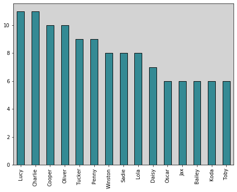

### Favorite Breeds:

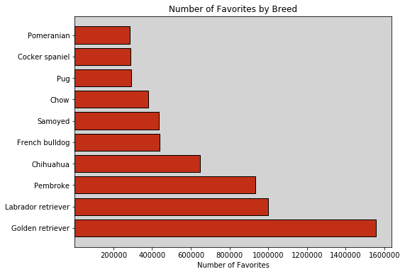

### Dog Stages:

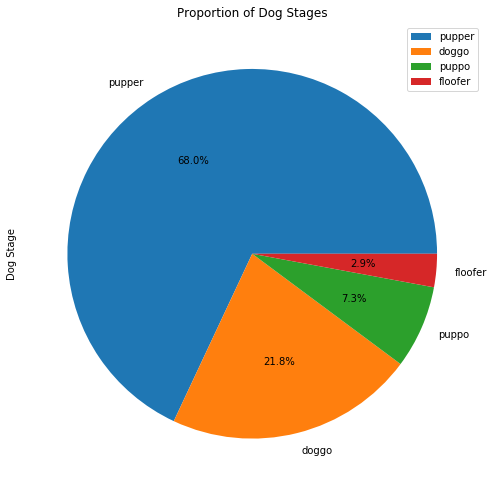

I analyzed the specific "dog stages", excluding the missing values to make a pie chart about the proportions of the categories. The most often used stage is "pupper" with more than 65%, the second one is "doggo" (about 22%). The account owners use the words puppo and floofer in 10% of the cases allctogether.

### Ratings:

[figure not shown]